# Redefining rows: Wide vs narrow data organization

Data Computing Chapter 12

Presenter: Olivia Beck Content credit: Matthew Beckman

## Cases, Variables, and Values

A data table is comprised of *cases* and *variables*.

Each *variable* comprises *values* (or levels).

There is no hard distinction between a variable and a value. What’s a variable in one situation may be a value in another, and vice versa.

Q: What IS different? Q: What is NOT different?

Table 2:

| region | year | num_nests |
| --- | --- | --- |
| Pacific | 2007 | 1039 |
| Pacific | 2009 | 2587 |
| Southwest | 2007 | 51 |
| Southwest | 2009 | 176 |
| Rocky Mountains and Plains | 2007 | 200 |
| Rocky Mountains and Plains | 2009 | 338 |

## Cases, Variables, and Values

#### For Table 1 ….

- Variables: `2007`, `2009`
  - Values:
    - `2007`: count of nests
    - `2009`: count of nests
- Cases: Regions {Pacific, Southwest, Rocky Mountains and Plains}

| region | 2007 | 2009 |
| --- | --- | --- |
| Pacific | 1039 | 2587 |
| Southwest | 51 | 176 |
| Rocky Mountains and Plains | 200 | 338 |

#### For Table 2

- Variables: `year`, `num_nests`
  - Values:
    - `year`: 2007 and 2009
    - `num_nests`: count of nests
- Cases: Regions and Year

| region | year | num_nests |
| --- | --- | --- |
| Pacific | 2007 | 1039 |
| Pacific | 2009 | 2587 |
| Southwest | 2007 | 51 |
| Southwest | 2009 | 176 |
| Rocky Mountains and Plains | 2007 | 200 |
| Rocky Mountains and Plains | 2009 | 338 |

Neither of the tables are wrong, but sometimes one form is more helpful than the other.

## Two formats

- Data in Key/Value format are **narrow**
  - possible to get *too* narrow if the meaning of case becomes awkward

| ID | Key | Value |
| --- | --- | --- |
| ID1 | Key1 | value(1,1) |
| ID1 | Key2 | value(1,2) |
| … | … | … |
| ID2 | Key1 | value(2,1) |
| ID2 | Key2 | value(2,2) |
| … | … | … |

- The corresponding **wide** format has
  - separate variables for each level in `key`
  - sets the values for those variables from the info in `value`

| ID | Key1 | Key2 | …. |
| --- | --- | --- | --- |
| ID1 | value(1,1) | value(1,2) | …. |
| ID2 | value(2,1) | value(2,2) | …. |
| … | … | … |  |

### Narrow

Let’s remember our original table:

```r
example_eagle_nests
```

| region | 2007 | 2009 |
| --- | --- | --- |
| Pacific | 1039 | 2587 |
| Southwest | 51 | 176 |
| Rocky Mountains and Plains | 200 | 338 |

Let’s make it narrow

```r
narrow_table <-
  example_eagle_nests %>%
  pivot_longer(
    cols = c(`2007`, `2009`),  #names of columns we want to become a new variable
    names_to = "year",         #what you want to call the new column of the data in the line above
    values_to = "num_nests"    #what you want to call the variable that stores the values
  )

narrow_table
```

| region | year | num_nests |
| --- | --- | --- |
| Pacific | 2007 | 1039 |
| Pacific | 2009 | 2587 |
| Southwest | 2007 | 51 |
| Southwest | 2009 | 176 |
| Rocky Mountains and Plains | 2007 | 200 |
| Rocky Mountains and Plains | 2009 | 338 |

Be careful you don’t make your tables too narrow where we loose the definition of a case (example on next slide).

### Wide

Let’s remember our narrow table.

```r
narrow_table
```

| region | year | num_nests |
| --- | --- | --- |
| Pacific | 2007 | 1039 |
| Pacific | 2009 | 2587 |
| Southwest | 2007 | 51 |
| Southwest | 2009 | 176 |
| Rocky Mountains and Plains | 2007 | 200 |
| Rocky Mountains and Plains | 2009 | 338 |

```r
NA
```

Now we can make our narrow table wide again.

```r
wide_table <-
  narrow_table %>%
  pivot_wider(
    names_from = year,       # the column in the narrow table with the column names for the wide table
    values_from = num_nests  # the column in the narrow table with the values in the narrow wide
  )

wide_table
```

| region | 2007 | 2009 |
| --- | --- | --- |
| Pacific | 1039 | 2587 |
| Southwest | 51 | 176 |
| Rocky Mountains and Plains | 200 | 338 |

We can compare this to the original table to make sure its the same thing. Yep!

```r
example_eagle_nests
```

| region | 2007 | 2009 |
| --- | --- | --- |
| Pacific | 1039 | 2587 |
| Southwest | 51 | 176 |
| Rocky Mountains and Plains | 200 | 338 |

## (Too) Narrow

Say this is the data set we have:

```r
class_example_Table
```

| region | 2007_Q1 | 2007_Q2 | 2007_Q3 | 2007_Q4 | 2009_Q1 | 2009_Q2 | 2009_Q3 | 2009_Q4 |
| --- | --- | --- | --- | --- | --- | --- | --- | --- |
| Pacific | 371 | 223 | 297 | 148 | 924 | 554 | 739 | 370 |
| Southwest | 18 | 11 | 15 | 7 | 63 | 38 | 50 | 25 |
| Rocky Mountains and Plains | 71 | 43 | 57 | 29 | 121 | 72 | 97 | 48 |

```r
NA
```

We can make it (appropriately) narrow like this:

```r
class_example_Table %>%
  pivot_longer(!region,                         #everything but region
               names_to = c("Year", "Quarter"),
               names_sep = "_",                  #how year and quarter are seperated
               values_to = "NestCount")
```

| region | Year | Quarter | NestCount |
| --- | --- | --- | --- |
| Pacific | 2007 | Q1 | 371 |
| Pacific | 2007 | Q2 | 223 |
| Pacific | 2007 | Q3 | 297 |
| Pacific | 2007 | Q4 | 148 |
| Pacific | 2009 | Q1 | 924 |
| Pacific | 2009 | Q2 | 554 |
| Pacific | 2009 | Q3 | 739 |
| Pacific | 2009 | Q4 | 370 |
| Southwest | 2007 | Q1 | 18 |
| Southwest | 2007 | Q2 | 11 |

[output cut: 14 more lines]

```r
NA
```

But we could have made it too narrow. None of the data has been lost here, but it’s not a helpful form since there isn’t a useful definition of “case”.

```r
names <- colnames(class_example_Table)

class_example_Table %>%
  mutate_all(as.character) %>%
  pivot_longer(cols = names,
               names_to = "key",
               values_to = "value")
```

| key | value |
| --- | --- |
| region | Pacific |
| 2007_Q1 | 371 |
| 2007_Q2 | 223 |
| 2007_Q3 | 297 |
| 2007_Q4 | 148 |
| 2009_Q1 | 924 |
| 2009_Q2 | 554 |
| 2009_Q3 | 739 |
| 2009_Q4 | 370 |
| region | Southwest |

[output cut: 17 more lines]

## So what?

- This allows us to easily redefine how rows are presented in the data
  - Possibly motivated by the research question
  - Possibly motivated by desire to join two data tables with different case definitions
  - Possibly motivated by a data visualization
- Also, some operations are easy in wide format, but hard in narrow and *vice versa*
- We need tools that make it easy to switch back and forth

## Example from `BabyNames`

| name | sex | count | year |
| --- | --- | --- | --- |
| Olivia | F | 17253 | 2012 |
| Olivia | M | 18 | 2012 |
| Olivia | F | 18256 | 2013 |
| Olivia | M | 21 | 2013 |
| Quentin | M | 625 | 2012 |
| Quentin | M | 722 | 2013 |
| Zoe | F | 6421 | 2012 |
| Zoe | M | 17 | 2012 |
| Zoe | F | 5920 | 2013 |
| Zoe | M | 15 | 2013 |

### Questions:

RQ 1. How many babies of each name and sex? RQ 2. For each name, is it primarily given to girls or boys? Which names are gender neutral?

## In narrow format

```r
data("BabyNames", package = "dcData")

BabyNames <-
  BabyNames %>%
  filter( name %in% c("Olivia", "Zoe", "Quentin", "Taylor"))
```

RQ 1. How many babies of each name and sex?

```r
BabyTotals <-
  BabyNames %>%
  group_by(name, sex) %>%
  summarise(total = sum(count))
```

| name | sex | total |
| --- | --- | --- |
| Olivia | F | 356529 |
| Olivia | M | 637 |
| Quentin | F | 179 |
| Quentin | M | 37669 |
| Taylor | F | 304305 |
| Taylor | M | 107264 |
| Zoe | F | 98859 |
| Zoe | M | 398 |

Easy!

## In Wide format

RQ 2. Which names are most gender neutral?

```
WideOutput <-
  NarrowInput %>%
  pivot_wider(names_from = var1, values_from = var2, values_fill = 0)
```

- we want a new column for each category of `sex`, so `names_from = sex`
  - we will “unstack” each available category as a new variable (a.k.a. cast, spread, unfold)
  - categories of `sex` were “F” and “M” in this example
- the values/entries for our new variables are coming from `total`, so `values_from = total`
  - `values_fill = 0` specifies a default value to fill when missing

```r
BabyTotalsWide <-
  BabyTotals %>%
  pivot_wider(names_from = sex, values_from = total, values_fill = 0)

BabyTotalsWide
```

| name | F | M |
| --- | --- | --- |
| Olivia | 356529 | 637 |
| Quentin | 179 | 37669 |
| Taylor | 304305 | 107264 |
| Zoe | 98859 | 398 |

## With sexes side by side…

We can easily calculate balance associated with names

```r
BabyTotalsWide <-
  BabyTotalsWide %>%
  rename(fem = F, male = M) %>%         # `F` is a terrible variable name (why?)
  mutate(prop_fem  = fem  / (male + fem),
         prop_male = male / (male + fem),
         name_specificity = pmax(prop_fem, prop_male))    # what does `pmax()` do?

BabyTotalsWide
```

| name | fem | male | prop_fem | prop_male | name_specificity |
| --- | --- | --- | --- | --- | --- |
| Olivia | 356529 | 637 | 0.998216516 | 0.001783484 | 0.9982165 |
| Quentin | 179 | 37669 | 0.004729444 | 0.995270556 | 0.9952706 |
| Taylor | 304305 | 107264 | 0.739377844 | 0.260622156 | 0.7393778 |
| Zoe | 98859 | 398 | 0.995990207 | 0.004009793 | 0.9959902 |

## `pivot_longer( )`—when you have “Wide” and want “Narrow”

Syntax:

```
NarrowOutput <-
  WideInput %>%
  pivot_longer(cols = c(wide_var1, wide_var2, ...), names_to = "long_var1", values_to "long_var2")
```

- The `cols` are the variables we want to combine (a.k.a. melt, stack, fold, gather)
- e.g. `prop_fem` and `prop_male` in this case

```r
BabyTotalsNarrow <-
  BabyTotalsWide %>%
  select(prop_fem, prop_male) %>%
  pivot_longer(cols = c(prop_fem, prop_male), names_to = "sex", values_to = "proportion")
BabyTotalsNarrow
```

| name | sex | proportion |
| --- | --- | --- |
| Olivia | prop_fem | 0.998216516 |
| Olivia | prop_male | 0.001783484 |
| Quentin | prop_fem | 0.004729444 |
| Quentin | prop_male | 0.995270556 |
| Taylor | prop_fem | 0.739377844 |
| Taylor | prop_male | 0.260622156 |
| Zoe | prop_fem | 0.995990207 |
| Zoe | prop_male | 0.004009793 |

## With sexes stacked again…

We can make an intuitive bar chart (though some clean up is needed…)

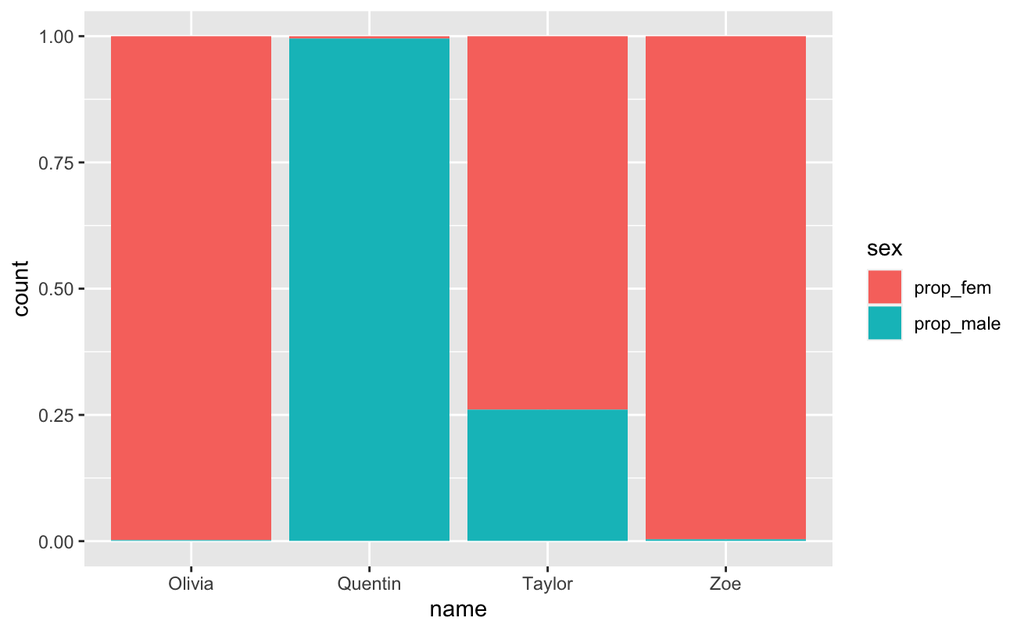

```r
BabyTotalsNarrow %>%
  ggplot() +
  geom_bar(aes(x = name, fill = sex, weight = proportion))
```

```r
NA
```

#### With some improvements

- clean up labels of sexes
- add title, source, & better axis labels (y-axis label had been flat wrong)

```r
# first, clean up the labels in `sex` for plotting
BabyTotalsNarrow %>%
  mutate(sex = if_else(sex == "prop_fem",
                       true = "female",
                       false = if_else(sex == "prop_male",
                                       true = "male",
                                       false = "unk")  # end of "inner" if_else()
                       )                               # ends the "outer" if_else()
         ) %>%                                         # ends the mutate()
  ggplot() +
  geom_bar(aes(x = name, fill = sex, weight = proportion)) +
  ggtitle("Gender Balance among Names of Beckman Kids",
          subtitle = "source: U.S. Social Security Administration") +
  xlab("Name") +
  ylab("Proportion")
```

[output not shown]